# Cleaning Data & Visualization

```python
import numpy as np
import pandas as pd
import re
import matplotlib.pyplot as plt
from scipy import stats
import seaborn as sns
```

```python
df=pd.read_csv(r"C:\Users\M. Sharath Kumar\ Web Scraping\Croma laptop dataset.csv")
```

```python
df
```

|  | Unnamed: 0 | Brand | Model | Processor | RAM | ROM | Screen Size | Weight(KG) | Color | Price | Old Price | Saving(rs) | Discount(%) |
| --- | --- | --- | --- | --- | --- | --- | --- | --- | --- | --- | --- | --- | --- |
| 0 | 0 | Apple | MacBook Air | M4 | 16GB | 256GB | 13.6 | NaN | Midnight | ₹95,990 | ₹99,900 | ₹3,910 | 4% Off |
| 1 | 1 | ASUS | TUF A16 FA607NUG-RL189WS | AMD Ryzen 7 | 16GB | 1TB SSD | 16.0 | 4.48 KG | Mecha Gray | ₹1,02,990 | ₹1,14,990 | ₹12,000 | 10% Off |
| 2 | 2 | Apple | MacBook Air | M4 | 24GB | 512GB | 13.6 | NaN | Starlight | ₹1,39,900 | NaN | NaN | NaN |
| 3 | 3 | HP | 15-fc0703AU | AMD Ryzen 5 | 16GB | 512GB | 15.6 | 1.59 KG | Natural Silver | ₹43,490 | ₹54,550 | ₹11,060 | 20% Off |
| 4 | 4 | Acer | Aspire Go 14 | Intel Core | 16GB | 512GB | 14.0 | 1.5 KG | Steel Gray | ₹56,990 | ₹72,999 | ₹16,009 | 22% Off |
| ... | ... | ... | ... | ... | ... | ... | ... | ... | ... | ... | ... | ... | ... |
| 529 | 529 | Lenovo | IdeaPad Slim 3 15IRH10 | Intel Core i7 | 16GB | 512GB | 15.3 | 1.59 KG | Luna Grey | ₹72,690 | ₹1,00,490 | ₹27,800 | 28% Off |
| 530 | 530 | Lenovo | Yoga 7 14IML9 | Intel Core | 16GB | 512GB | 14.0 | 1.49 KG | Storm Grey | ₹94,990 | ₹1,25,890 | ₹30,900 | 25% Off |
| 531 | 531 | HP | OmniBook 7 14-fr0116TU | Intel Core | 32GB | 1TB SSD | 14.0 | 1.41 KG | Meteor Silver Aluminum | ₹1,14,990 | ₹1,32,302 | ₹17,312 | 13% Off |
| 532 | 532 | HP | OmniBook 7 14-fr0789TU | Intel Core | 16GB | 1TB SSD | 14.0 | 1.41 KG | Meteor Silver Aluminum | ₹86,990 | ₹1,25,971 | ₹38,981 | 31% Off |
| 533 | 533 | HP | 14-gr0006TU | Intel Core | 16GB | 512GB | 14.0 | 1.41 KG | Natural Silver | ₹57,490 | ₹79,900 | ₹22,410 | 28% Off |

534 rows × 13 columns

```python
df.drop(columns='Unnamed: 0',inplace=True)
```

```python
df
```

|  | Brand | Model | Processor | RAM | ROM | Screen Size | Weight(KG) | Color | Price | Old Price | Saving(rs) | Discount(%) |
| --- | --- | --- | --- | --- | --- | --- | --- | --- | --- | --- | --- | --- |
| 0 | Apple | MacBook Air | M4 | 16GB | 256GB | 13.6 | NaN | Midnight | ₹95,990 | ₹99,900 | ₹3,910 | 4% Off |
| 1 | ASUS | TUF A16 FA607NUG-RL189WS | AMD Ryzen 7 | 16GB | 1TB SSD | 16.0 | 4.48 KG | Mecha Gray | ₹1,02,990 | ₹1,14,990 | ₹12,000 | 10% Off |
| 2 | Apple | MacBook Air | M4 | 24GB | 512GB | 13.6 | NaN | Starlight | ₹1,39,900 | NaN | NaN | NaN |
| 3 | HP | 15-fc0703AU | AMD Ryzen 5 | 16GB | 512GB | 15.6 | 1.59 KG | Natural Silver | ₹43,490 | ₹54,550 | ₹11,060 | 20% Off |
| 4 | Acer | Aspire Go 14 | Intel Core | 16GB | 512GB | 14.0 | 1.5 KG | Steel Gray | ₹56,990 | ₹72,999 | ₹16,009 | 22% Off |
| ... | ... | ... | ... | ... | ... | ... | ... | ... | ... | ... | ... | ... |
| 529 | Lenovo | IdeaPad Slim 3 15IRH10 | Intel Core i7 | 16GB | 512GB | 15.3 | 1.59 KG | Luna Grey | ₹72,690 | ₹1,00,490 | ₹27,800 | 28% Off |
| 530 | Lenovo | Yoga 7 14IML9 | Intel Core | 16GB | 512GB | 14.0 | 1.49 KG | Storm Grey | ₹94,990 | ₹1,25,890 | ₹30,900 | 25% Off |
| 531 | HP | OmniBook 7 14-fr0116TU | Intel Core | 32GB | 1TB SSD | 14.0 | 1.41 KG | Meteor Silver Aluminum | ₹1,14,990 | ₹1,32,302 | ₹17,312 | 13% Off |
| 532 | HP | OmniBook 7 14-fr0789TU | Intel Core | 16GB | 1TB SSD | 14.0 | 1.41 KG | Meteor Silver Aluminum | ₹86,990 | ₹1,25,971 | ₹38,981 | 31% Off |
| 533 | HP | 14-gr0006TU | Intel Core | 16GB | 512GB | 14.0 | 1.41 KG | Natural Silver | ₹57,490 | ₹79,900 | ₹22,410 | 28% Off |

534 rows × 12 columns

```python
sns.kdeplot(df['price'],color='red')
```

[output not shown]

```python
df.info()
```

```
<class 'pandas.core.frame.DataFrame'>
RangeIndex: 534 entries, 0 to 533
Data columns (total 12 columns):
 #   Column       Non-Null Count  Dtype
---  ------       --------------  -----
 0   Brand        534 non-null    object
 1   Model        534 non-null    object
 2   Processor    486 non-null    object
 3   RAM          529 non-null    object
 4   ROM          496 non-null    object
 5   Screen Size  510 non-null    float64
 6   Weight(KG)   394 non-null    object
 7   Color        513 non-null    object
 8   Price        531 non-null    object
 9   Old Price    482 non-null    object
 10  Saving(rs)   482 non-null    object
 11  Discount(%)  482 non-null    object
dtypes: float64(1), object(11)
memory usage: 50.2+ KB
```

```python
df.isnull().sum()
```

```
Brand            0
Model            0
Processor       48
RAM              5
ROM             38
Screen Size     24
Weight(KG)     140
Color           21
Price            3
Old Price       52
Saving(rs)      52
Discount(%)     52
dtype: int64
```

```python
df.head()
```

|  | Brand | Model | Processor | RAM | ROM | Screen Size | Weight(KG) | Color | Price | Old Price | Saving(rs) | Discount(%) |
| --- | --- | --- | --- | --- | --- | --- | --- | --- | --- | --- | --- | --- |
| 0 | Apple | MacBook Air | M4 | 16GB | 256GB | 13.6 | NaN | Midnight | ₹95,990 | ₹99,900 | ₹3,910 | 4% Off |
| 1 | ASUS | TUF A16 FA607NUG-RL189WS | AMD Ryzen 7 | 16GB | 1TB SSD | 16.0 | 4.48 KG | Mecha Gray | ₹1,02,990 | ₹1,14,990 | ₹12,000 | 10% Off |
| 2 | Apple | MacBook Air | M4 | 24GB | 512GB | 13.6 | NaN | Starlight | ₹1,39,900 | NaN | NaN | NaN |
| 3 | HP | 15-fc0703AU | AMD Ryzen 5 | 16GB | 512GB | 15.6 | 1.59 KG | Natural Silver | ₹43,490 | ₹54,550 | ₹11,060 | 20% Off |
| 4 | Acer | Aspire Go 14 | Intel Core | 16GB | 512GB | 14.0 | 1.5 KG | Steel Gray | ₹56,990 | ₹72,999 | ₹16,009 | 22% Off |

## Changing data Types and removeing units

```python
def clean_currency(value):
    if pd.isna(value) or value is np.nan:
        return np.nan

    clean_str = re.sub(r'[^\d.]', '', str(value))
    return int(clean_str) if clean_str else np.nan


for col in ['Price', 'Old Price', 'Saving(rs)']:
    df[col] = df[col].apply(clean_currency)
```

```python
df['Discount(%)'] = df['Discount(%)'].astype(str).str.extract(r'(\d+)').astype(float) #removeing %
```

```python
 df['RAM_GB'] = df['RAM'].astype(str).str.extract(r'(\d+)').astype(float)
```

```python
def clean_rom(value):
    # Handle NaN or already numeric values early
    if pd.isna(value):
        return np.nan

    # Force value to string and uppercase for consistent checking
    val = str(value).upper()

    # Use regex to find the numeric part
    numbers = re.findall(r'\d+', val)
    if not numbers:
        return np.nan

    numeric_val = float(numbers[0])

    # Convert TB to GB
    if 'TB' in val:
        return numeric_val * 1024
    return numeric_val

# Apply the function
df['ROM_GB'] = df['ROM'].apply(clean_rom)
```

```python
# Convert to string first, then replace, then convert to float
df['Weight(KG)'] = df['Weight(KG)'].astype(str).str.replace('KG', '', case=False).astype(float)
```

```python
df.drop(columns='Brand')
```

[output not shown]

534 rows × 11 columns

```python
df
```

|  | Brand | Model | Processor | RAM | ROM | Screen Size | Weight(KG) | Color | Price | Old Price | Saving(rs) | Discount(%) | RAM_GB | ROM_GB |
| --- | --- | --- | --- | --- | --- | --- | --- | --- | --- | --- | --- | --- | --- | --- |
| 0 | Apple | MacBook Air | M4 | 16GB | 256GB | 13.6 | NaN | Midnight | 95990.0 | 99900.0 | 3910.0 | 4.0 | 16.0 | 256.0 |
| 1 | ASUS | TUF A16 FA607NUG-RL189WS | AMD Ryzen 7 | 16GB | 1TB SSD | 16.0 | 4.48 | Mecha Gray | 102990.0 | 114990.0 | 12000.0 | 10.0 | 16.0 | 1024.0 |
| 2 | Apple | MacBook Air | M4 | 24GB | 512GB | 13.6 | NaN | Starlight | 139900.0 | NaN | NaN | NaN | 24.0 | 512.0 |
| 3 | HP | 15-fc0703AU | AMD Ryzen 5 | 16GB | 512GB | 15.6 | 1.59 | Natural Silver | 43490.0 | 54550.0 | 11060.0 | 20.0 | 16.0 | 512.0 |
| 4 | Acer | Aspire Go 14 | Intel Core | 16GB | 512GB | 14.0 | 1.50 | Steel Gray | 56990.0 | 72999.0 | 16009.0 | 22.0 | 16.0 | 512.0 |
| ... | ... | ... | ... | ... | ... | ... | ... | ... | ... | ... | ... | ... | ... | ... |
| 529 | Lenovo | IdeaPad Slim 3 15IRH10 | Intel Core i7 | 16GB | 512GB | 15.3 | 1.59 | Luna Grey | 72690.0 | 100490.0 | 27800.0 | 28.0 | 16.0 | 512.0 |
| 530 | Lenovo | Yoga 7 14IML9 | Intel Core | 16GB | 512GB | 14.0 | 1.49 | Storm Grey | 94990.0 | 125890.0 | 30900.0 | 25.0 | 16.0 | 512.0 |
| 531 | HP | OmniBook 7 14-fr0116TU | Intel Core | 32GB | 1TB SSD | 14.0 | 1.41 | Meteor Silver Aluminum | 114990.0 | 132302.0 | 17312.0 | 13.0 | 32.0 | 1024.0 |
| 532 | HP | OmniBook 7 14-fr0789TU | Intel Core | 16GB | 1TB SSD | 14.0 | 1.41 | Meteor Silver Aluminum | 86990.0 | 125971.0 | 38981.0 | 31.0 | 16.0 | 1024.0 |
| 533 | HP | 14-gr0006TU | Intel Core | 16GB | 512GB | 14.0 | 1.41 | Natural Silver | 57490.0 | 79900.0 | 22410.0 | 28.0 | 16.0 | 512.0 |

534 rows × 14 columns

```python
df.drop(columns=['RAM','ROM'],inplace=True)
```

```python
df.head()
```

|  | Brand | Model | Processor | Screen Size | Weight(KG) | Color | Price | Old Price | Saving(rs) | Discount(%) | RAM_GB | ROM_GB |
| --- | --- | --- | --- | --- | --- | --- | --- | --- | --- | --- | --- | --- |
| 0 | Apple | MacBook Air | M4 | 13.6 | NaN | Midnight | 95990.0 | 99900.0 | 3910.0 | 4.0 | 16.0 | 256.0 |
| 1 | ASUS | TUF A16 FA607NUG-RL189WS | AMD Ryzen 7 | 16.0 | 4.48 | Mecha Gray | 102990.0 | 114990.0 | 12000.0 | 10.0 | 16.0 | 1024.0 |
| 2 | Apple | MacBook Air | M4 | 13.6 | NaN | Starlight | 139900.0 | NaN | NaN | NaN | 24.0 | 512.0 |
| 3 | HP | 15-fc0703AU | AMD Ryzen 5 | 15.6 | 1.59 | Natural Silver | 43490.0 | 54550.0 | 11060.0 | 20.0 | 16.0 | 512.0 |
| 4 | Acer | Aspire Go 14 | Intel Core | 14.0 | 1.50 | Steel Gray | 56990.0 | 72999.0 | 16009.0 | 22.0 | 16.0 | 512.0 |

```python
df.info()
```

```
<class 'pandas.core.frame.DataFrame'>
RangeIndex: 534 entries, 0 to 533
Data columns (total 12 columns):
 #   Column       Non-Null Count  Dtype
---  ------       --------------  -----
 0   Brand        534 non-null    object
 1   Model        534 non-null    object
 2   Processor    486 non-null    object
 3   Screen Size  510 non-null    float64
 4   Weight(KG)   394 non-null    float64
 5   Color        513 non-null    object
 6   Price        531 non-null    float64
 7   Old Price    482 non-null    float64
 8   Saving(rs)   482 non-null    float64
 9   Discount(%)  482 non-null    float64
 10  RAM_GB       529 non-null    float64
 11  ROM_GB       496 non-null    float64
dtypes: float64(8), object(4)
memory usage: 50.2+ KB
```

```python
df.isnull().sum()
```

```
Brand            0
Model            0
Processor       48
Screen Size     24
Weight(KG)     140
Color           21
Price            3
Old Price       52
Saving(rs)      52
Discount(%)     52
RAM_GB           5
ROM_GB          38
dtype: int64
```

## Filling missing values

```python
# List of numerical columns with nulls
num_cols = ['Processor', 'Screen Size', 'Weight(KG)', 'Price', 'Old Price', 'Saving(rs)', 'Discount(%)']

# Fill numerical nulls with the median
for col in num_cols:
    if df[col].dtype != 'object':
        df[col] = df[col].fillna(df[col].median())
```

```python
# Fill Processor and Color with the most common value
df['Processor'] = df['Processor'].fillna(df['Processor'].mode()[0])
df['Color'] = df['Color'].fillna(df['Color'].mode()[0])
```

```python
# Specifically fill RAM and ROM nulls with the most common configuration (e.g., 8GB or 16GB)
df['RAM_GB'] = df['RAM_GB'].fillna(df['RAM_GB'].mode()[0])
df['ROM_GB'] = df['ROM_GB'].fillna(df['ROM_GB'].mode()[0])

# Convert them to Int64 now that nulls are gone
df['RAM_GB'] = df['RAM_GB'].astype(int)
df['ROM_GB'] = df['ROM_GB'].astype(int)
```

```python
df.isna().sum()
```

```
Brand          0
Model          0
Processor      0
Screen Size    0
Weight(KG)     0
Color          0
Price          0
Old Price      0
Saving(rs)     0
Discount(%)    0
RAM_GB         0
ROM_GB         0
dtype: int64
```

```python
df.info()
```

```
<class 'pandas.core.frame.DataFrame'>
RangeIndex: 534 entries, 0 to 533
Data columns (total 12 columns):
 #   Column       Non-Null Count  Dtype
---  ------       --------------  -----
 0   Brand        534 non-null    object
 1   Model        534 non-null    object
 2   Processor    534 non-null    object
 3   Screen Size  534 non-null    float64
 4   Weight(KG)   534 non-null    float64
 5   Color        534 non-null    object
 6   Price        534 non-null    float64
 7   Old Price    534 non-null    float64
 8   Saving(rs)   534 non-null    float64
 9   Discount(%)  534 non-null    float64
 10  RAM_GB       534 non-null    int64
 11  ROM_GB       534 non-null    int64
dtypes: float64(6), int64(2), object(4)
memory usage: 50.2+ KB
```

```python
df.head()
```

|  | Brand | Model | Processor | Screen Size | Weight(KG) | Color | Price | Old Price | Saving(rs) | Discount(%) | RAM_GB | ROM_GB |
| --- | --- | --- | --- | --- | --- | --- | --- | --- | --- | --- | --- | --- |
| 0 | Apple | MacBook Air | M4 | 13.6 | 1.62 | Midnight | 95990.0 | 99900.0 | 3910.0 | 4.0 | 16 | 256 |
| 1 | ASUS | TUF A16 FA607NUG-RL189WS | AMD Ryzen 7 | 16.0 | 4.48 | Mecha Gray | 102990.0 | 114990.0 | 12000.0 | 10.0 | 16 | 1024 |
| 2 | Apple | MacBook Air | M4 | 13.6 | 1.62 | Starlight | 139900.0 | 104703.0 | 21799.0 | 21.0 | 24 | 512 |
| 3 | HP | 15-fc0703AU | AMD Ryzen 5 | 15.6 | 1.59 | Natural Silver | 43490.0 | 54550.0 | 11060.0 | 20.0 | 16 | 512 |
| 4 | Acer | Aspire Go 14 | Intel Core | 14.0 | 1.50 | Steel Gray | 56990.0 | 72999.0 | 16009.0 | 22.0 | 16 | 512 |

```python
df.to_csv(r"laptop_dataset.csv")
```

```python
df = pd.read_csv('laptop_dataset.csv')
```

```python
df
```

[output not shown]

534 rows × 13 columns

# Univariate Analysis

```python
df['RAM_GB'].unique()
```

```
array([16, 24, 12, 18, 32, 56, 36, 48])
```

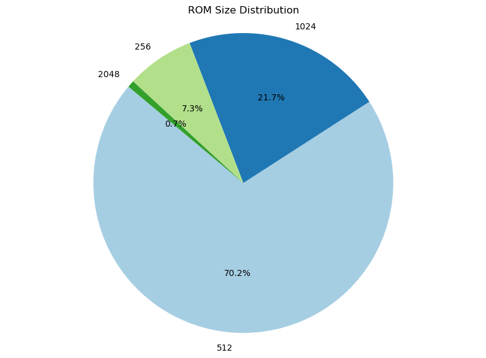

```python
import matplotlib.pyplot as plt

# 1. Prepare the data (count the occurrences of each ROM size)
rom_counts = df['ROM_GB'].value_counts()

# 2. Create the pie chart using matplotlib
plt.figure(figsize=(10, 7))
plt.pie(rom_counts,
        labels=rom_counts.index,
        autopct='%1.1f%%',
        startangle=140,
        colors=plt.cm.Paired.colors)

plt.title('ROM Size Distribution')
plt.axis('equal')  # Ensures the pie is a circle
plt.show()
```

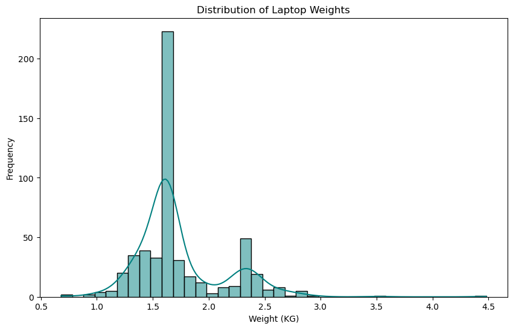

```python
plt.figure(figsize=(10, 6))
sns.histplot(df['Weight(KG)'].dropna(), kde=True, color='teal',binwidth=0.1)
plt.xticks(np.arange(0.5, 5.0, 0.5))
plt.title('Distribution of Laptop Weights')
plt.xlabel('Weight (KG)')
plt.ylabel('Frequency')
plt.show()
```

## 1. Price Distribution (Are these budget or luxury laptops?)

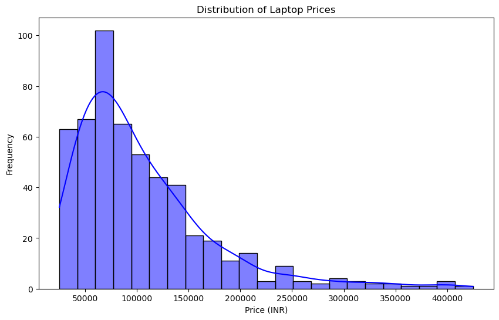

```python
import matplotlib.pyplot as plt
import seaborn as sns

plt.figure(figsize=(10, 6))
sns.histplot(df['Price'], kde=True, color='blue')
plt.title('Distribution of Laptop Prices')
plt.xlabel('Price (INR)')
plt.ylabel('Frequency')
plt.show()
```

# Bivariate Analysis

#### 1.Screen Size vs Price: Larger Screens show a Slight Price Increase

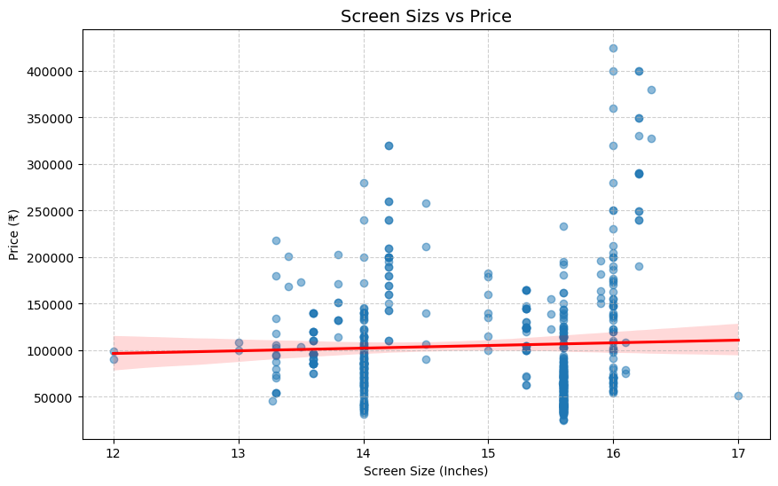

```python
plt.figure(figsize=(10, 6))

# Creating the scatter plot with a regression line
sns.regplot(data=df, x='Screen Size', y='Price',
            scatter_kws={'alpha':0.5},
            line_kws={'color':'red'})

# Simple heading including the core insight
plt.title( 'Screen Sizs vs Price', fontsize=14)

plt.xlabel('Screen Size (Inches)')
plt.ylabel('Price (₹)')
plt.grid(True, linestyle='--', alpha=0.6)
```

## 2. Brand vs. Average Price (Which brand is most expensive?)

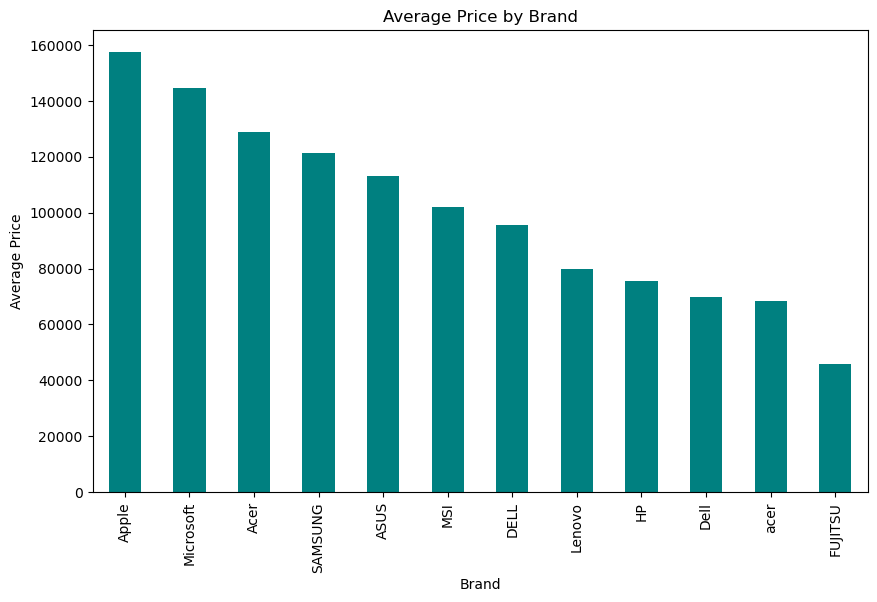

```python
brand_price = df.groupby('Brand')['Price'].mean().sort_values(ascending=False)
brand_price.plot(kind='bar', figsize=(10,6), color='teal')
plt.title('Average Price by Brand')
plt.ylabel('Average Price')
plt.show()
```

## 3. RAM vs. Price (How much does extra memory cost?)

[output not shown]

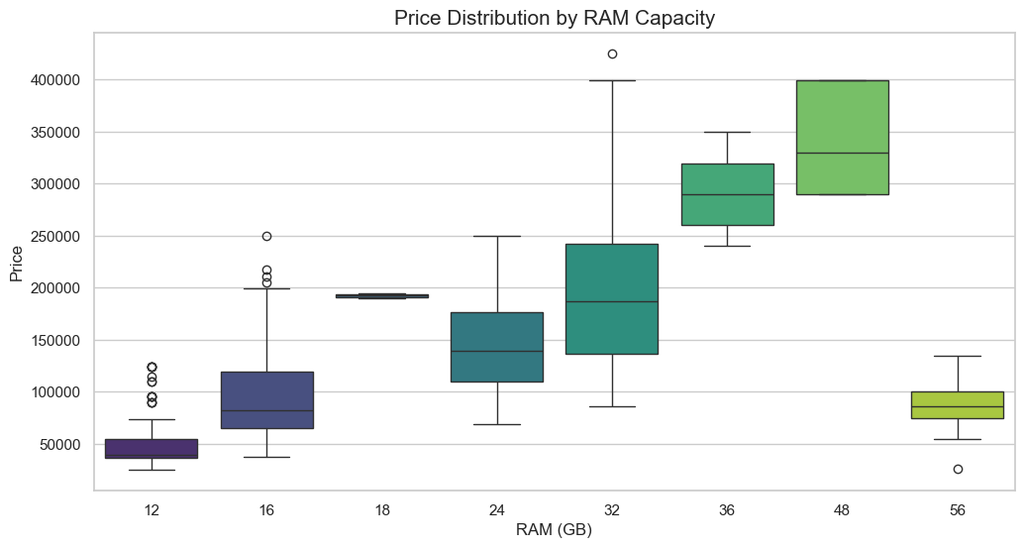

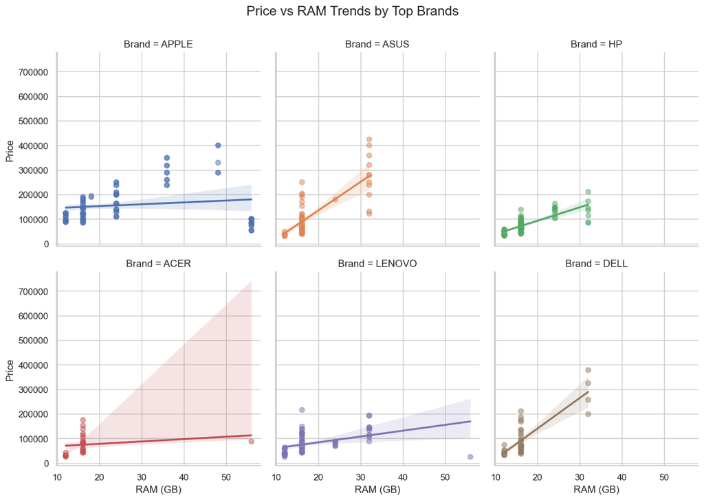

```python
import seaborn as sns
import matplotlib.pyplot as plt

# 1. Clean the 'Brand' column (fix the 'Acer' vs 'acer' issue)
df['Brand'] = df['Brand'].str.upper()

# 2. Set the aesthetic style
sns.set_theme(style="whitegrid")

# --- Visualization A: Boxplot (Best for Price Distribution) ---
plt.figure(figsize=(12, 6))
sns.boxplot(x='RAM_GB', y='Price', data=df, palette='viridis')
plt.title('Price Distribution by RAM Capacity', fontsize=15)
plt.xlabel('RAM (GB)', fontsize=12)
plt.ylabel('Price', fontsize=12)
plt.show()

# --- Visualization B: Faceted Regression (Best for Brand Comparison) ---
# This creates a separate small graph for each major brand to avoid overlap
top_brands = df['Brand'].value_counts().nlargest(6).index
df_top = df[df['Brand'].isin(top_brands)]

g = sns.lmplot(
    data=df_top, x="RAM_GB", y="Price", col="Brand",
    hue="Brand", col_wrap=3, height=4, scatter_kws={'alpha':0.5}
)
g.set_axis_labels("RAM (GB)", "Price")
g.fig.suptitle('Price vs RAM Trends by Top Brands', y=1.05, fontsize=16)
plt.show()
```

## 4. Discount Analysis (Which brand offers the biggest deals?)

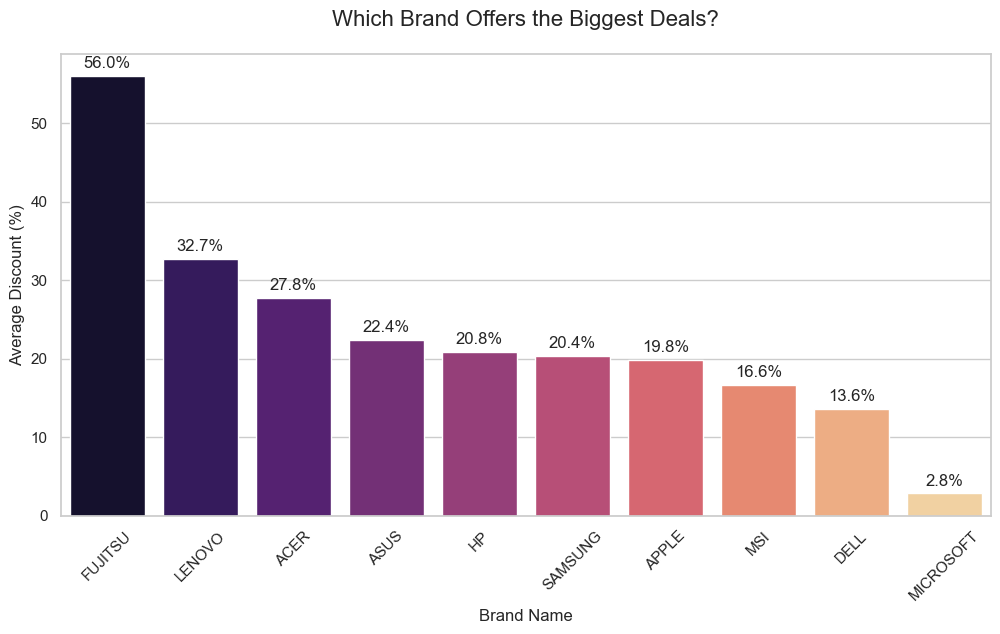

```python
avg_discount = df.groupby('Brand')['Discount(%)'].mean().sort_values(ascending=False).reset_index()

sns.set_theme(style="whitegrid")
plt.figure(figsize=(12, 6))

plot = sns.barplot(x='Brand', y='Discount(%)', data=avg_discount, palette='magma')

# 4. Add the actual percentage values on top of the bars for better clarity
for p in plot.patches:
    plot.annotate(format(p.get_height(), '.1f') + '%',
                   (p.get_x() + p.get_width() / 2., p.get_height()),
                   ha = 'center', va = 'center',
                   xytext = (0, 9),
                   textcoords = 'offset points')

# 5. Final touches
plt.title('Which Brand Offers the Biggest Deals?', fontsize=16, pad=20)
plt.xlabel('Brand Name', fontsize=12)
plt.ylabel('Average Discount (%)', fontsize=12)
plt.xticks(rotation=45)

plt.show()
```

### How Processor Choice is Impacting the Laptop Price

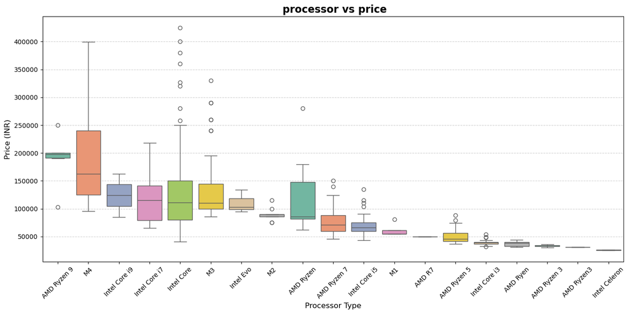

```python
processor_order = df.groupby('Processor')['Price'].median().sort_values(ascending=False).index

# 3. Create the Box Plot
plt.figure(figsize=(14, 7))
sns.boxplot(data=df, x='Processor', y='Price', order=processor_order, palette='Set2')

# 4. Add professional labels and titles
plt.title(' processor vs price', fontsize=16, fontweight='bold')
plt.xlabel('Processor Type', fontsize=12)
plt.ylabel('Price (INR)', fontsize=12)
plt.xticks(rotation=45) # Rotates labels so they don't overlap
plt.grid(axis='y', linestyle='--', alpha=0.6)

# 5. Save the plot
plt.tight_layout()
plt.savefig('processor_impact_chart.png')
```

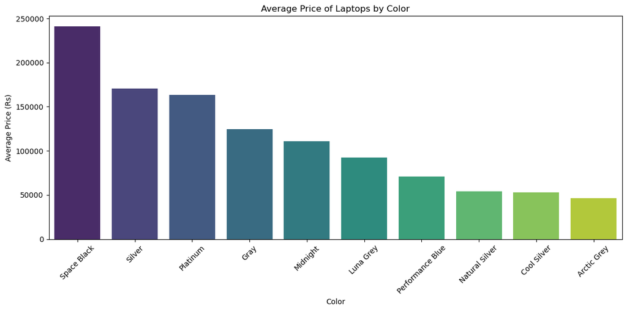

```python
top_10_colors = df['Color'].value_counts().nlargest(10).index.tolist()

# 2. Filter the dataframe to include only these top 10 colors
df_top_colors = df[df['Color'].isin(top_10_colors)]

# 3. Calculate the average price for each color and sort them
mean_prices = df_top_colors.groupby('Color')['Price'].mean().sort_values(ascending=False).reset_index()

# 4. Create the Bar Plot
plt.figure(figsize=(12, 6))
sns.barplot(data=mean_prices, x='Color', y='Price', palette='viridis')

# 5. Add titles and labels for clarity
plt.title('Average Price of Laptops by Color')
plt.ylabel('Average Price (Rs)')
plt.xlabel('Color')
plt.xticks(rotation=45)
plt.tight_layout()

# 6. Save or show the visual
plt.savefig('average_price_by_color.png')
plt.show()
```

# Multivariate Analysis

### To check which features (RAM, ROM, Weight, Screen Size) have the strongest "pull" on the price.

```python
df['Price'].corr(df['RAM_GB'])
```

```
np.float64(0.4523868085390453)
```

```python
df['Price'].corr(df['ROM_GB'])
```

```
np.float64(0.399051290397244)
```

```python
df['Price'].corr(df['Weight(KG)'])
```

```
np.float64(0.15107992992881647)
```

```python
df['Price'].corr(df['Screen Size'])
```

```
np.float64(0.03899603313525477)
```

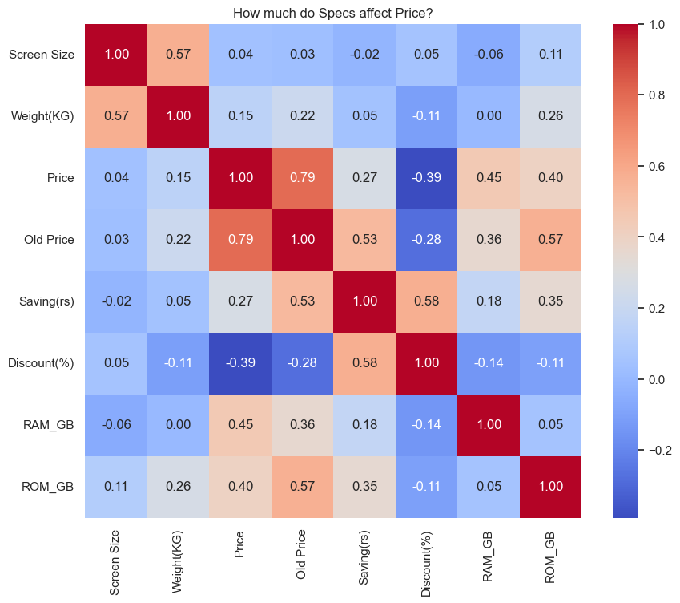

```python
# Select only numeric columns for correlation
numeric_df = df.select_dtypes(include=['float64', 'int64', 'Int64'])
correlation = numeric_df.corr()

plt.figure(figsize=(10, 8))
sns.heatmap(correlation, annot=True, cmap='coolwarm', fmt=".2f")
plt.title('How much do Specs affect Price?')
plt.show()
```

```python
import warnings
warnings.filterwarnings('ignore')
```

```python
# Calculate Performance Score
# We weight RAM higher (0.8) than ROM (0.05) because RAM has a bigger impact on speed.
df['Performance_Score'] = (df['RAM_GB'] * 0.8) + (df['ROM_GB'] * 0.05)
```

## The "Power User" (High Specs, Mid Price)

[figure not shown]

```python
import matplotlib.pyplot as plt
import seaborn as sns

# 1. DEFINE THE LOGIC (Re-creating the missing columns)
def score_processor(proc):
    proc = str(proc).upper()
    if 'M4' in proc or 'RYZEN 7' in proc or 'I7' in proc: return 10
    if 'RYZEN 5' in proc or 'I5' in proc: return 7
    if 'RYZEN 3' in proc or 'I3' in proc: return 4
    return 2

# 2. APPLY THE LOGIC (This creates the 'Processor_Score' column you were missing)
df['Processor_Score'] = df['Processor'].apply(score_processor)

# 3. CALCULATE PERFORMANCE & VFM
df['Enhanced_Performance'] = (df['RAM_GB'] * 0.4) + (df['Processor_Score'] * 4) + (df['ROM_GB'] / 128)
df['Business_VFM'] = (df['Enhanced_Performance'] / df['Price']) * 10000

# 4. FILTER FOR TOP 5
power_users = df[(df['RAM_GB'] >= 16) & (df['Processor_Score'] >= 7)]
power_picks = power_users.sort_values(by='Business_VFM', ascending=False).head(5)

# 5. CREATE THE VISUAL
plt.figure(figsize=(12, 6))
ax = sns.barplot(x='Business_VFM', y='Model', data=power_picks, palette='viridis')

# Add Price labels on the bars for extra detail
for i, price in enumerate(power_picks['Price']):
    ax.text(0.1, i, f' Price: ₹{price:,.0f}', va='center', color='white', fontweight='bold')

plt.title('Top 5 Power User Laptops (Best Value for Money)', fontsize=15)
plt.xlabel('Value Score')
plt.ylabel('Laptop Model')
plt.show()
```

## VFM Score,Category,Business Meaning

- 9.0 - 10.0 --> Excellent,High-end specs at a budget price; likely a massive discount.
- 7.0 - 8.9 --> Great,Solid hardware for a very fair market price.
- 5.0 - 6.9 --> Average,Standard pricing; you get exactly what you pay for.
- Below 5.0 --> Premium,"You are paying for the Brand name, build quality, or thinness."

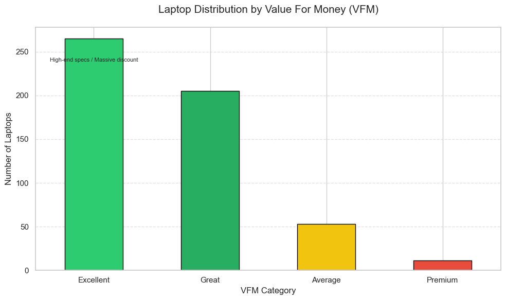

```python
import matplotlib.pyplot as plt
import pandas as pd

# 1. Clean the data (fill missing values with 0 so the math works)
df['Discount(%)'] = df['Discount(%)'].fillna(0)
df['RAM_GB'] = df['RAM_GB'].fillna(8)  # Assume 8GB if missing
df['ROM_GB'] = df['ROM_GB'].fillna(256) # Assume 256GB if missing

# 2. Calculate a balanced VFM Score (0 to 10 scale)
# This formula gives points for Discount, RAM, and Storage
df['VFM_Score'] = (df['Discount(%)'] * 0.15) + (df['RAM_GB'] * 0.2) + (df['ROM_GB'] * 0.004)

# 3. Define the categories based on YOUR specific ranges
def get_category(score):
    if score >= 9.0:
        return 'Excellent'
    elif score >= 7.0:
        return 'Great'
    elif score >= 5.0:
        return 'Average'
    else:
        return 'Premium'

# Apply the categories to a new column
df['VFM_Category'] = df['VFM_Score'].apply(get_category)

# 4. Count the results and sort them in order
# We use 'reindex' to make sure the bars appear in order of quality
order = ['Excellent', 'Great', 'Average', 'Premium']
category_counts = df['VFM_Category'].value_counts().reindex(order).fillna(0)

# 5. Create the Visualization
plt.figure(figsize=(10, 6))
colors = ['#2ecc71', '#27ae60', '#f1c40f', '#e74c3c'] # Green, Dark Green, Yellow, Red

category_counts.plot(kind='bar', color=colors, edgecolor='black')

# Add labels and titles
plt.title('Laptop Distribution by Value For Money (VFM)', fontsize=15, pad=20)
plt.xlabel('VFM Category', fontsize=12)
plt.ylabel('Number of Laptops', fontsize=12)
plt.xticks(rotation=0)
plt.grid(axis='y', linestyle='--', alpha=0.6)

# Optional: Add the business meanings as text on the plot
plt.text(0, category_counts.max()*0.9, "High-end specs / Massive discount", fontsize=8, ha='center')

plt.tight_layout()
plt.show()
```

## Hypothesis Testing

```python
df['Brand'].unique()
```

```
array(['APPLE', 'ASUS', 'HP', 'ACER', 'LENOVO', 'DELL', 'MICROSOFT',
       'SAMSUNG', 'MSI', 'FUJITSU'], dtype=object)
```

```python
import pandas as pd

# 1. Load the dataset
df = pd.read_csv('laptop_dataset.csv')

# 2. Group by Brand and aggregate Price statistics
brand_stats = df.groupby('Brand')['Price'].agg(['count', 'mean', 'std', 'min', 'max'])

# 3. Rename columns for a professional look
brand_stats.columns = ['Count', 'Mean Price (RS)', 'Std Dev', 'Min Price', 'Max Price']

# 4. Sort by Mean Price in descending order to match your request
brand_stats = brand_stats.sort_values(by='Mean Price (RS)', ascending=False)

# 5. Display the DataFrame
# In a Jupyter Notebook, simply typing 'brand_stats' at the end of a cell renders a beautiful table.
brand_stats
```

[output not shown]

# Assumptions

#### Null Hypothesis (H0): The average price is the same for all brands. (Brand doesn't matter).

#### Alternative Hypothesis (H1): At least one brand has a significantly different average price compared to the others

```python
# Only includeing brands with more than one laptop for valid statistics
brand_counts = df['Brand'].value_counts()
valid_brands = brand_counts[brand_counts > 1].index
df_filtered = df[df['Brand'].isin(valid_brands)]

# Create groups of prices for each brand
brand_groups = [df_filtered[df_filtered['Brand'] == brand]['Price'] for brand in valid_brands]
```

#### ANOVA Test

###### This calculates the F-statistic and the p-value.

```python
# Perform One-Way ANOVA
f_stat, p_val = stats.f_oneway(*brand_groups)

print(f"F-statistic: {f_stat}")
print(f"p-value: {p_val}")
```

```
F-statistic: 18.435729091618313
p-value: 2.044798984906327e-24
```

##### Rule: If p < 0.05, we reject the Null Hypothesis.

- Tested brand influence on laptop prices. +Performed One-Way ANOVA statistical analysis.
- High F-score shows significant brand differences.
- Near-zero p-value proves results are real.
- Rejected Null Hypothesis; Brand name matters.
- Statistical data confirms brand price variation.
- Math proves brands charge premium prices.

[figure not shown]

```python
plt.figure(figsize=(12, 6))
# Sorting brands by mean price for a clearer visual
order = df_filtered.groupby('Brand')['Price'].mean().sort_values(ascending=False).index

sns.boxplot(x='Brand', y='Price', data=df_filtered, order=order)
plt.title('Average Price Variation by Brand')
plt.xticks(rotation=45)
plt.show()
```

#### Summary for the test case:

- Test used: One-Way ANOVA.
- Finding: Confirmed that the "Brand" factor is statistically significant ($p < 0.05$).
- Observation: Brands like Apple and Microsoft have a higher "Brand Premium" compared to Acer and HP, which target the budget-friendly segment.